# HW 8 - MCMC

Eunchong Kang

03/12/2022

```r
# library set-up
library(tidyverse)
```

# Importance and Rejection Sampling

Write the form of the integral pertaining to $\sigma^2 = E[X^2]$ and $p(x) = c \cdot q(x) =c \cdot \exp({−|x|^3/3})$

solution:
$$E(X^2) = \int x^2 \cdot p(x) dx = \int x^2 \cdot c \cdot q(x) dx = \int x^2 \cdot c \cdot e^{\frac{-|x|^3}{3}} dx$$

## 1. Find the estimate for $\sigma^2$ using importance sampling.

Write the expression for the integral using an importance sampling scheme, then carry out this approximation of the expectation.

solution:  
Let $g(x) = \frac{1}{\sqrt{2\pi}}e^{-\frac{x^2}{2}}$, which means $g \sim N(0,1)$, and this would be a good choice because $g(x)$ covers the support of $q(x)$ and has a fatter tail. The re-expression of the integral is below.

$$E(X^2) = \int x^2 \cdot c \cdot \frac{q(x)}{g(x)}g(x) dx = \int x^2 \cdot c \cdot \frac{e^{\frac{-|x|^3}{3}}}{\frac{1}{\sqrt{2\pi}}e^{-\frac{x^2}{2}}}\frac{1}{\sqrt{2\pi}}e^{-\frac{x^2}{2}} dx$$

The approximation is below.
$$E(X^2) \approx \frac{1}{M} \sum_{k=1}^M x_k^2 \cdot c \cdot w^*(x_k) = \frac{c}{M} \sum_{k=1}^M x_k^2 \frac{e^{\frac{-|x_k|^3}{3}}}{\frac{1}{\sqrt{2\pi}}e^{-\frac{x_k^2}{2}}}$$

where $x_k$s are random samples from standard normal distribution.

```r
## Create helper functions
# h(x) = x^2 function
h_x <- function(x){
        value <- x^2
        return(value)
}

# q(x) function
q_x <- function(x){
        value <- exp(-abs(x)^3/3)
        return(value)
}

## Approximate the integral
# set M
M = 10^5

# Draw M samples from g(x) = standard normal distribution
set.seed(1)
y_imp <- rnorm(M, 0, 1)

# Compute importance weights
w_star <- q_x(y_imp) / dnorm(y_imp)

# Compute MC estimate of integral
mean(h_x(y_imp)*w_star)
```

```
## [1] 2.003655
```

Since
$$\int c \cdot e^{\frac{-|x|^3}{3}} dx = 1 \Leftrightarrow \int e^{\frac{-|x|^3}{3}} dx = \frac{1}{c},$$
$c$ can be calculated by the code below.

```r
# Sample x for calculating c
set.seed(2)
y_c <- rnorm(M, 0, 1)

# compute weights for calculating c
w_star_c <- q_x(y_c) / dnorm(y_c)

# Approximate c
1/mean(w_star_c)
```

```
## [1] 0.3881499
```

Therefore, the estimated $E(X^2)$ is below.

```r
# Calculate E(x^2)
1/mean(w_star_c)*mean(h_x(y_imp)*w_star)
```

```
## [1] 0.7777186
```

## 2. Repeat the procedure using rejection sampling.

Write out the form of the integral and then its approximation based on rejection sampling.

solution:  
It is necessary to find $e(x)$, $g(x)$, and $\alpha$ such that $e(x) = \frac{g(x)}{\alpha} > q(x)$ and $\alpha \leq 1$.  
Put $g(x) = \frac{1}{\sqrt{2\pi}}e^{-\frac{x^2}{2}}$ again. Note that $g(x)$ is always greater than $q(x)$ when $|x| \geq 1$, and $g(x)$ and $q(x)$ are even functions. Thus, it is needed to compare the above inequality only when $0 < x < 1$  
The inequality can be simplified into the below.

$$e(x) = \frac{1}{\sqrt{2\pi}}e^{-\frac{x^2}{2}}\frac{1}{\alpha} > e^{-\frac{x^3}{3}} \Leftrightarrow \,
...\, \Leftrightarrow log(\frac{1}{\alpha\sqrt{2\pi}}) > \frac{x^2}{2}-\frac{x^3}{3}$$

Here, $\frac{x^2}{2}-\frac{x^3}{3}$ has the maximum value of $\frac{1}{6}$ at $x = 1$ on $0<x<1$.  
Therefore, one can put $log(\frac{1}{\alpha\sqrt{2\pi}}) > \frac{1}{6}$, which is equivalent to $\alpha < \frac{1}{\sqrt{2\pi}e^{1/6}} = 0.3376973...$.

Now, put $\alpha=0.3$ then $e(x) = \frac{g(x)}{0.3}$.

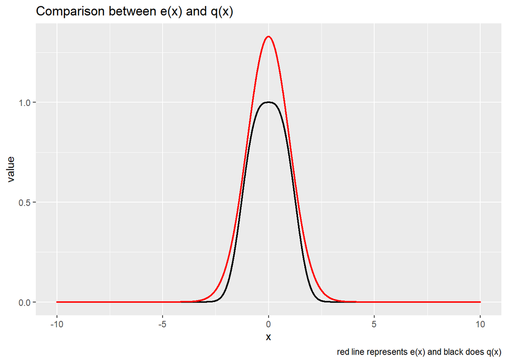

```r
# Confirm g(x)/alpha > q(x)
x <- seq(-10, 10, length.out = 10000)
set.seed(3)
dt <- data.frame(x=x, e=dnorm(x)/0.3, q=q_x(x))

ggplot(dt) +
        geom_point(aes(x, q),size=0.3) +
        geom_point(aes(x, e), size=0.3, color="red") +
        labs(title = "Comparison between e(x) and q(x)",
             caption = "red line represents e(x) and black does q(x)") +
        ylab("value")
```

The graph above shows $e(x) > q(x)$ on the real line.  
The code to implement the rejection sampling and approximate the integral is below.

```r
# The number of samples to keep
M <- 10^5

# In case of alpha is low
maxit <- M * 10^4

# Specify vector storing samples
smpl <- rep(0,M)

# Start rejection algorithm
i <- index <- 1

while (i <= M & index < maxit){
        # Sample from N(0,1)
        candidate <- rnorm(1,0,1)

        # Sample from U(0,1)
        Ui <- runif(1,0,1)

        # Calculate ratio
        r <- 0.3 * q_x(candidate) / dnorm(candidate)

        # Check Ui vs r
        if (Ui < r){
                smpl[i] <- candidate
                i <- i + 1
        }

        # Keep track of total number of sampling
        index <- index + 1
}

# Calculate the approximation of E(x^2)
mean(smpl^2)
```

```
## [1] 0.7751872
```

```r
# Calculate acceptance rate
print(M / index)
```

```
## [1] 0.7723737
```